# Korozja — test t dla dwóch grup niezależnych

Wersja studencka do rozwiązania

Materiały do laboratorium — Język R / Data Science

11.05.2026

# 1 Cel ćwiczenia

W tym ćwiczeniu wykonujemy kompletną, ale skróconą analizę danych z wykorzystaniem **testu t dla dwóch prób niezależnych**.

Zajęcia dotyczą przede wszystkim języka R, dlatego najważniejsze jest przećwiczenie pełnej ścieżki programistycznej:

1. wczytanie danych,
2. przygotowanie zmiennych,
3. opis danych w grupach,
4. wykonanie wykresu,
5. sprawdzenie podstawowych założeń,
6. wykonanie testu t,
7. uzupełnienie wyniku o wielkość efektu,
8. sformułowanie krótkiego wniosku.

Przy okazji powtarzamy podstawową logikę analizy statystycznej: najpierw oglądamy dane, potem dobieramy test, a na końcu interpretujemy wynik.

# 2 Opis problemu badawczego

W doświadczeniu porównano dwie rury kanalizacyjne zabezpieczone dwoma typami powłok. Rury zakopano w identycznych warunkach glebowych i pozycyjnych oraz w tym samym czasie.

Mierzono korozję, wyrażając głębokość uszkodzeń w tysięcznych częściach milimetra. Wykonano 30 pomiarów:

- 15 pomiarów dla powłoki A,
- 15 pomiarów dla powłoki B.

Pytanie badawcze brzmi:

> Czy przeciętna głębokość uszkodzeń różni się pomiędzy dwoma rodzajami powłok?

# 3 Zmienne w analizie

| Zmienna w badaniu | Rola w analizie | Typ zmiennej |
| --- | --- | --- |
| głębokość uszkodzenia | zmienna zależna | ilościowa |
| rodzaj powłoki | zmienna grupująca | jakościowa nominalna, 2 grupy |

Ponieważ porównujemy zmienną ilościową w dwóch niezależnych grupach, odpowiednim kandydatem jest **test t dla dwóch prób niezależnych**.

# 4 Przygotowanie środowiska

## 4.1 Instalacja pakietów

Poniższy kod należy uruchomić tylko wtedy, gdy któryś z pakietów nie jest jeszcze zainstalowany.

```r
install.packages(c(
  "tidyverse",   # praca z danymi i wykresy
  "car",         # test Levene'a
  "broom",       # porządkowanie wyników testów
  "effectsize",  # wielkości efektu
  "knitr",       # estetyczne tabele w R Markdown
  "pwr"          # analiza mocy testu
))
```

## 4.2 Wczytanie bibliotek

```r
library(tidyverse)
library(car)
library(broom)
library(effectsize)
library(knitr)
library(pwr)
```

## 4.3 Parametry analizy

Poziom istotności zapisujemy w osobnym obiekcie. Dzięki temu, gdybyśmy chcieli zmienić poziom istotności, robimy to tylko w jednym miejscu.

```r
alpha <- 0.05
```

# 5 Wczytanie danych

Zakładamy, że plik `Korozja.csv` znajduje się w tym samym folderze co plik RMD.

```r
data_file <- "Korozja.csv"

if (!file.exists(data_file)) {
  stop("Nie znaleziono pliku Korozja.csv w bieżącym folderze roboczym.")
}

raw_data <- readr::read_delim(
  file = data_file,
  delim = ";",
  locale = readr::locale(decimal_mark = ","),
  trim_ws = TRUE,
  show_col_types = FALSE
)
```

# 6 Przygotowanie danych

W pliku źródłowym kolumny mają polskie nazwy. W danych nie jest to problemem, ale w kodzie wygodniej używać prostych nazw roboczych. Dlatego tworzymy nową ramkę danych z nazwami:

- `coating_type` - rodzaj powłoki,
- `damage_depth` - głębokość uszkodzenia.

```r
corrosion_data <- raw_data

names(corrosion_data) <- c("coating_type", "damage_depth")

corrosion_data <- corrosion_data |>
  dplyr::mutate(
    coating_type = factor(coating_type),
    damage_depth = as.numeric(damage_depth)
  ) |>
  tidyr::drop_na(coating_type, damage_depth)
```

> **Dobra praktyka programistyczna**  
> W kodzie R warto unikać polskich znaków w nazwach obiektów i kolumn roboczych. Dane mogą mieć polskie etykiety, ale kod jest zwykle stabilniejszy i czytelniejszy, gdy używamy prostych nazw technicznych.

# 7 Kontrola danych

## 7.1 Struktura ramki danych

Sprawdź strukturę przygotowanej ramki danych `corrosion_data`. Zwróć uwagę na typy zmiennych: `damage_depth` powinna być zmienną liczbową, a `coating_type` zmienną grupującą.

```r
glimpse(corrosion_data)
```

```
## Rows: 30
## Columns: 2
## $ coating_type <fct> A, A, A, A, A, A, A, A, A, A, A, A, A, A, A, B, B, B, B, …
## $ damage_depth <dbl> 73, 43, 47, 53, 58, 47, 52, 38, 61, 56, 56, 34, 55, 65, 7…
```

## 7.2 Liczebności grup

Sprawdź liczebności obserwacji dla każdego typu powłoki. Wykorzystaj zmienną grupującą `coating_type`.

```r
corrosion_data |>
  dplyr::count(coating_type)
```

| coating_type | n |
| --- | --- |
| A | 15 |
| B | 15 |

W każdej grupie powinno być 15 obserwacji. Taki układ jest **zrównoważony**, czyli obie porównywane grupy mają taką samą liczebność.

# 8 Definicja problemu statystycznego

Interesuje nas zależność:

```
damage_depth ~ coating_type
```

czyli sprawdzamy, czy wartości zmiennej ilościowej `damage_depth` różnią się pomiędzy dwoma poziomami zmiennej grupującej `coating_type`.

Hipotezy dla testu t są następujące:

**Hipoteza zerowa H0:**

> Przeciętna głębokość uszkodzeń jest taka sama dla obu powłok.

**Hipoteza alternatywna H1:**

> Przeciętna głębokość uszkodzeń różni się pomiędzy powłokami.

Wykonujemy test dwustronny, ponieważ interesuje nas dowolna różnica pomiędzy powłokami, a nie wyłącznie sytuacja, w której jedna konkretna powłoka ma większą albo mniejszą średnią głębokość uszkodzeń.

# 9 Wstępna eksploracja danych

## 9.1 Statystyki opisowe w grupach

Oblicz podstawowe statystyki opisowe zmiennej `damage_depth` osobno dla każdego typu powłoki. Wyniki posortuj malejąco według średniej.

```r
group_summary <- corrosion_data |>
  dplyr::group_by(coating_type) |>
  dplyr::summarise(
    n      = dplyr::n(),
    mean   = mean(damage_depth),
    median = median(damage_depth),
    sd     = sd(damage_depth),
    min    = min(damage_depth),
    max    = max(damage_depth),
    .groups = "drop"
  ) |>
  dplyr::arrange(dplyr::desc(mean))

group_summary |>
  knitr::kable(
    digits = 2,
    caption = "Statystyki opisowe głębokości uszkodzeń w grupach"
  )
```

Statystyki opisowe głębokości uszkodzeń w grupach

| coating_type | n | mean | median | sd | min | max |
| --- | --- | --- | --- | --- | --- | --- |
| A | 15 | 54.2 | 55 | 11.58 | 34 | 75 |
| B | 15 | 46.2 | 44 | 10.77 | 24 | 68 |

Komentarz: średnia głębokość uszkodzeń jest wyższa w grupie powłoki A niż w grupie powłoki B. Różnica na poziomie opisowym wynosi około 8 jednostek pomiarowych. Nie oznacza to jeszcze, że różnica jest statystycznie istotna.

## 9.2 Wykres ramka-wąsy z punktami

Wykres ramka-wąsy pokazuje medianę, rozrzut wyników i obserwacje odstające. Punkty dodane na wykresie pokazują pojedyncze pomiary.

Przygotuj wykres ramka-wąsy pokazujący wartości zmiennej `damage_depth` w grupach wyznaczonych przez zmienną `coating_type`.  
Na wykresie powinny znaleźć się również pojedyncze obserwacje jako punkty. W razie potrzeby skorzystaj z funkcji z pakietu `ggplot2`, np. `ggplot()`, `aes()`, `geom_boxplot()`, `geom_jitter()`, `labs()` i `theme_minimal()`.

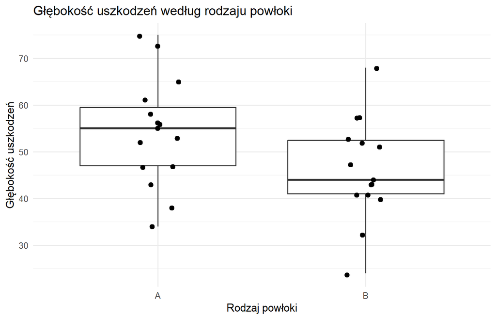

```r
ggplot(corrosion_data, aes(x = coating_type, y = damage_depth, group = coating_type)) +
  geom_boxplot() +
  geom_jitter(
    width = 0.1,
    size = 2,
    alpha = 1
  ) +
  labs(
    title = "Głębokość uszkodzeń według rodzaju powłoki",
    x = "Rodzaj powłoki",
    y = "Głębokość uszkodzeń"
  ) +
  theme_minimal()
```

Interpretacja wykresu: wyniki dla powłoki A są przeciętnie wyższe niż dla powłoki B, ale rozkłady obu grup częściowo się nakładają. Widzimy więc różnicę opisową, ale potrzebny jest test statystyczny, aby ocenić, czy jest ona istotna statystycznie.

# 10 Sprawdzenie założeń testu t

## 10.1 Normalność rozkładu w grupach

Test Shapiro-Wilka sprawdza hipotezę zerową, że dane pochodzą z rozkładu normalnego. Wykonujemy go osobno dla każdej grupy.

Wykonaj test Shapiro-Wilka osobno dla każdego typu powłoki. Wynik zapisz w obiekcie `shapiro_results`. Tabela powinna zawierać nazwę grupy, wartość statystyki testowej oraz wartość p.  
Wskazówka: możesz wykorzystać funkcje `group_by()` i `summarise()` z pakietu `dplyr` oraz funkcję `shapiro.test()`.

```r
corrosion_data |> group_by(coating_type) |>
  summarise(statistic = shapiro.test(damage_depth)$stat, p_value = shapiro.test(damage_depth)$p.value) |>
  mutate(across(where(is.numeric), ~ sprintf("%.4f", .x)))
```

| coating_type | statistic | p_value |
| --- | --- | --- |
| A | 0.9752 | 0.9262 |
| B | 0.9746 | 0.9191 |

W obu grupach wartości p w testach Shapiro-Wilka są większe od przyjętego poziomu istotności α = 0,05. Nie mamy więc podstaw do odrzucenia założenia normalności w żadnej z grup.

## 10.2 Wykresy Q-Q

Test Shapiro-Wilka warto uzupełnić wykresami Q-Q. Jeżeli punkty układają się w przybliżeniu wzdłuż linii referencyjnej, rozkład danych można uznać za zbliżony do normalnego.

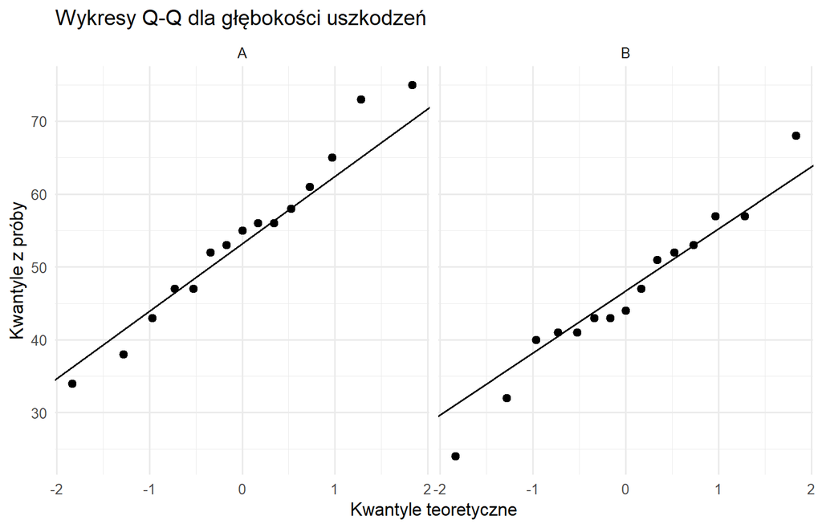

```r
ggplot(corrosion_data, aes(sample = damage_depth)) +
  stat_qq(size = 2) +
  stat_qq_line() +
  facet_wrap(~ coating_type) +
  labs(
    title = "Wykresy Q-Q dla głębokości uszkodzeń",
    x = "Kwantyle teoretyczne",
    y = "Kwantyle z próby"
  ) +
  theme_minimal()
```

Na wykresach Q-Q punkty układają się w przybliżeniu wzdłuż linii referencyjnej. Nie widać wyraźnego naruszenia założenia normalności.

## 10.3 Jednorodność wariancji — test Levene’a

Test Levene’a sprawdza hipotezę zerową o równości wariancji w grupach. Jeżeli p > 0,05, nie mamy podstaw do odrzucenia założenia o podobnych wariancjach.

Wykonaj test Levene’a dla zmiennej `damage_depth` w grupach wyznaczonych przez zmienną `coating_type`.  
Wskazówka: użyj funkcji `car::leveneTest()` oraz zapisu formułowego: `zmienna_liczbowa ~ zmienna_grupująca`. W argumencie `data` wskaż ramkę danych `corrosion_data`.

```r
car::leveneTest(
  damage_depth ~ coating_type,
  data = corrosion_data
)
```

|  | Df | F value | Pr(>F) |
| --- | --- | --- | --- |
| group | 1 | 0.05107 | 0.8229 |
|  | 28 | NA | NA |

Wartość p w teście Levene’a jest większa od α = 0,05, więc nie mamy podstaw do odrzucenia hipotezy o jednorodności wariancji. Oznacza to, że założenie podobieństwa wariancji można uznać za spełnione.

# 11 Test t-Studenta dla dwóch prób niezależnych

Ponieważ diagnostyka nie wskazała na istotne naruszenie założeń normalności i jednorodności wariancji, możemy zastosować klasyczny test t-Studenta dla dwóch prób niezależnych.

Wykonaj test t-Studenta, w którym zmienną zależną jest `damage_depth`, a zmienną grupującą jest `coating_type`. Wskazówka: użyj funkcji `t.test()` oraz zapisu formułowego: `zmienna_liczbowa ~ zmienna_grupująca`.

W R domyślna funkcja `t.test()` wykonuje test Welcha. Aby wykonać klasyczny test t-Studenta z założeniem równych wariancji, należy ustawić argument `var.equal = TRUE`.

```r
student_t_result <- t.test(damage_depth ~ coating_type, data = corrosion_data, var.equal = TRUE)
```

## 11.1 Tabela wyników testu

Wynik testu możemy przekształcić do wygodnej tabeli za pomocą funkcji `broom::tidy()`.

**Uwaga!** Poniższy fragment zadziała poprawnie tylko wtedy, gdy w poprzednim kroku zapisano wynik testu w obiekcie `student_t_result`.

```r
student_t_table <- broom::tidy(student_t_result) |>
  dplyr::mutate(dplyr::across(where(is.numeric), ~ round(.x, 4)))

student_t_table |>
  knitr::kable(caption = "Wyniki testu t-Studenta")
```

Wyniki testu t-Studenta

| estimate | estimate1 | estimate2 | statistic | p.value | parameter | conf.low | conf.high | method | alternative |
| --- | --- | --- | --- | --- | --- | --- | --- | --- | --- |
| 8 | 54.2 | 46.2 | 1.959 | 0.0601 | 28 | -0.3635 | 16.36 | Two Sample t-test | two.sided |

## 11.2 Interpretacja wyniku testu

Wynik testu t-Studenta nie był istotny statystycznie:

*t*(28) = 1,959; p = 0,0601.

Ponieważ wartość p jest większa od α = 0,05, nie mamy podstaw do odrzucenia hipotezy zerowej o równości średnich. Oznacza to, że na podstawie tych danych nie wykazano statystycznie istotnej różnicy przeciętnej głębokości uszkodzeń pomiędzy powłoką A i powłoką B.

Bardzo ważne: nie mówimy, że średnie są na pewno takie same. Mówimy ostrożniej: **na podstawie tych danych nie wykazano statystycznie istotnej różnicy średnich**.

## 11.3 Przedział ufności dla różnicy średnich

Test t zwraca również 95% przedział ufności dla różnicy średnich.

**Uwaga!** Ten fragment korzysta z obiektu `student_t_result` utworzonego w poprzednim kroku.

```r
mean_difference <- unname(
  student_t_result$estimate[1] - student_t_result$estimate[2]
)

confidence_interval <- student_t_result$conf.int

mean_difference
```

```
## [1] 8
```

```r
confidence_interval
```

```
## [1] -0.3635 16.3635
## attr(,"conf.level")
## [1] 0.95
```

Różnica średnich A - B wynosi około 8,00. Natomiast 95% przedział ufności dla tej różnicy wynosi od około -0,36 do około 16,36.

Ponieważ przedział ufności obejmuje 0, wynik jest spójny z decyzją testu: różnica nie jest statystycznie istotna na poziomie α = 0,05.

# 12 Wielkość efektu

Wartość p mówi, czy efekt jest statystycznie istotny przy danej liczebności próby i zmienności danych. Nie mówi jednak wprost, jak duża jest różnica.

Dlatego obliczymy **d Cohena**, czyli standaryzowaną różnicę średnich.

Oblicz d Cohena dla porównania grup `A` i `B`. Wynik zapisz w obiekcie `cohens_d_result`.

Wskazówka: użyj funkcji `effectsize::cohens_d()` oraz zapisu formułowego: `zmienna_liczbowa ~ zmienna_grupująca`. Przyjmij wspólne odchylenie standardowe dla obu grup (`pooled_sd = TRUE`) i wyznacz 95% przedział ufności.

```r
cohens_d_result <- effectsize::cohens_d(
  damage_depth ~ coating_type,
  data = corrosion_data,
  pooled_sd = TRUE
)

cohens_d_result |>
  as_tibble() |>
  transmute(
    cohens_d = round(Cohens_d, 4),
    CI = CI,
    CI_low = round(CI_low, 4),
    CI_high = round(CI_high, 4)
  )
```

| cohens_d | CI | CI_low | CI_high |
| --- | --- | --- | --- |
| 0.7155 | 0.95 | -0.0301 | 1.449 |

Wartość d Cohena wynosi około 0,72, czyli różnica średnich odpowiada około 0,72 wspólnego odchylenia standardowego. Jest to efekt umiarkowany do dość dużego. W tym przykładzie efekt jest widoczny opisowo, ale przy liczebności 15 obserwacji w każdej grupie wynik testu nie osiągnął przyjętego progu istotności statystycznej.

W analizie mocy traktujemy otrzymane d Cohena jako przybliżenie efektu, który chcielibyśmy wykrywać w przyszłym, podobnym eksperymencie. Nie oznacza to, że taka wielkość efektu jest na pewno prawdziwa w populacji.

### 12.0.1 Zadanie dodatkowe (dodatkowy 1 punkt)

Na podstawie obliczonej wcześniej wielkości efektu d Cohena oszacuj, jaka powinna być minimalna liczebność próby w każdej grupie, aby w analogicznym eksperymencie moc dwustronnego testu t-Studenta wynosiła 80%, przy poziomie istotności α = 0,05.

Wskazówka: możesz wykorzystać funkcję `pwr::pwr.t.test()`. Pamiętaj, że w funkcji tej argument `n` oznacza liczebność w każdej z dwóch grup.

```r
# Wskazówka:
# 1. Wyciągnij wartość d Cohena z obiektu cohens_d_result.
# 2. Użyj wartości bezwzględnej efektu.
# 3. Wykorzystaj funkcję pwr::pwr.t.test().
# 4. Zaokrąglij wynik w górę, ponieważ liczebność próby musi być liczbą całkowitą.
```

Otrzymana wartość `n` oznacza szacowaną liczebność w każdej z dwóch grup. Wynik należy zaokrąglić w górę. Obliczenie to zakłada, że w przyszłym, analogicznym eksperymencie rzeczywista wielkość efektu byłaby podobna do tej zaobserwowanej w analizowanej próbie.

# 13 Końcowy wniosek

Przeprowadzono test t-Studenta dla dwóch prób niezależnych w celu sprawdzenia, czy przeciętna głębokość uszkodzeń różni się pomiędzy dwoma rodzajami powłok. Wstępna diagnostyka nie wskazała na istotne naruszenie założeń normalności i jednorodności wariancji.

Średnia głębokość uszkodzeń była wyższa dla powłoki A niż dla powłoki B. Różnica średnich wyniosła około 8,00 jednostek pomiarowych. Wynik testu nie był jednak istotny statystycznie: *t*(28) = 1,959; p = 0,0601. Na poziomie istotności α = 0,05 nie mamy podstaw do odrzucenia hipotezy zerowej o równości średnich.

Wielkość efektu była umiarkowana do dość dużej (**d Cohena ≈ 0,72**), co wskazuje, że zaobserwowana różnica była zauważalna opisowo. Jednocześnie należy podkreślić, że na podstawie tych danych nie wykazano statystycznie istotnej różnicy przeciętnej głębokości uszkodzeń pomiędzy porównywanymi powłokami.

# 14 Najczęstsze błędy w tej analizie

1. **Mylenie testu dla prób niezależnych z testem dla prób zależnych**  
   Test dla prób zależnych stosujemy wtedy, gdy mierzymy te same obiekty dwa razy lub mamy naturalnie sparowane obserwacje. Tutaj traktujemy grupy jako niezależne.
2. **Użycie domyślnego `t.test()` bez świadomości, co robi R**  
   Domyślnie `t.test()` wykonuje test Welcha. Klasyczny test t-Studenta z założeniem równych wariancji wymaga argumentu `var.equal = TRUE`.
3. **Stwierdzenie, że średnie są identyczne**  
   Brak istotności statystycznej nie oznacza, że średnie są na pewno takie same. Oznacza, że w danych nie ma wystarczających podstaw do wykazania różnicy.
4. **Interpretowanie p = 0,0601 jako „prawie istotne”**  
   Wynik jest blisko progu 0,05, ale przy przyjętym poziomie istotności nie spełnia kryterium istotności statystycznej.
5. **Nadmierne poleganie tylko na wartości p**  
   Warto patrzeć także na średnie, odchylenia standardowe, wykresy, przedział ufności i wielkość efektu.